Heliconius exploration project site [GitHub](https://github.com/wyatt-toure/heliconius-exploration) Analysis Methods Home

# Analysis for ‘Does persistent colour preference constrain behavioural flexibility in Heliconius butterflies?’

M. Wyatt Toure

e-mail: `wyatt.toure@gmail.com`

## Brief Overview

This page details the analysis performed for ‘untitled Heliconius exploration project’. I walk through all the data preparation steps and models here and explain my reasoning for analysis decisions. If you are only interested in the model outputs you can go straight to the Models section. The code to reproduce this analysis are embedded within the code to generate this page which is in the [`analysis.Rmd`](https://github.com/wyatt-toure/heliconius-exploration/blob/main/analysis.Rmd) file. The data underlying this analysis are available in the [`/data`](https://github.com/wyatt-toure/heliconius-exploration/blob/main/data) directory. Instructions on how to run the analyses as well as metadata for the variables can be found in [README.md](https://github.com/wyatt-toure/heliconius-exploration#how-to-reproduce-the-results).

## Background

One of the things I noticed while I was doing an experiment on Heliconiini time-based learning was that some individuals did not switch colours very much between time sessions, even though the flower was actively punished. This can be seen below where I plot the proportion of correct choices made during all of training.

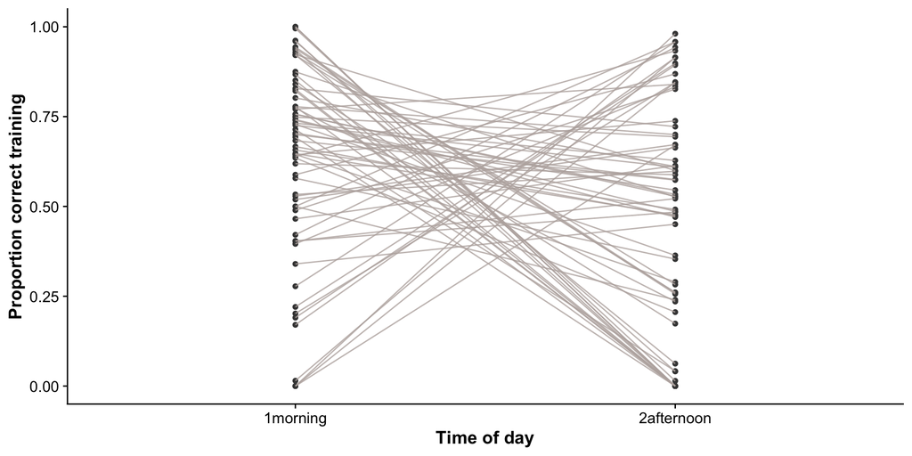

Figure 1: The proportion of correct choice an individual made during the morning and the afternoon throughout all of training. Lines connect individual acoss time periods.

Some of these lines have steeper slopes than others. Since the correct choice in the morning is incorrect in the afternoon, this means that steep slopes indicate individuals who stuck with their ‘favourite’ colour (stubborn). The less steep the slope, the more flexible an individual was. I was interested in whether these steep sloped individuals were generally less exploratory/flexible than their comparatively less stubborn counterparts.

For this experiment we wanted to understand the following:

1. Are stubborn (steep sloped) individuals less likely to sample a novel colour (Model 1)?
2. Does the stubborn group remain stubborn during exploration trials? Do they always stick with their favourite colour (Model 3)?

To get at this I gave butterflies exploration trials where familiar colours (yellow or purple) were paired with novel colours which the butterflies had never seen before.

## Data preparation

### Exploration assay data

The raw data for the exploration experiment are in the form of individual choices associated with an individual ID as well as the cage identity and the two colours present in the assay.

```r
## Read in data
exploration_data <- read.csv("data/heliconius-exploration-data-raw.csv")

## ID to factor
exploration_data$id <- as.factor(exploration_data$id)
```

#### Standardise combination names

Here I standardise the levels of the variable `combo` so that the colour combinations are all in the same order with the familiar colour first and the novel colour second.

```r
## Renaming factor levels
## Old name is on the left, new name is on the right
exploration_data$combo <- recode_factor(exploration_data$combo,
                                                    "blue-purple" = 'purple-blue',
                                                    "blue-yellow" = 'yellow-blue',
                                                    "dblue-purple" = 'purple-blue',
                                                   "lblue-yellow" = 'yellow-lblue',
                                                    "orange-purple" = 'purple-orange',
                                                    "pink-purple" = 'purple-pink',
                                                    "pink-yellow" = 'yellow-pink',
                                                    "red-purple" = 'purple-red',
                                                   "red-yellow" = 'yellow-red'
                                                   )
```

#### Summarise raw counts

I tabulated the raw data into their totals using a custom function `summarise_exploration_data()`. You can see the code for this function [here](https://github.com/wyatt-toure/heliconius-exploration/blob/main/R/tidy-exploration-data.R).

```r
## Applying summarise exploration data function
exploration_data_summarised <- summarise_exploration_data(exploration_data)
```

#### Assign time of day and rewarding colours

Next I needed to assign the time of day for the trials as well as their original session rewarding colours from the learning experment. This was done with a series of cage-specific `case_when()` and `mutate()` statements. This section is quite long so I have folded the code, you can click the show code tab to see the code.

```r
# Assigning time of day to assays
exploration_data_summarised <- exploration_data_summarised %>%
  mutate(
    time.of.day = case_when(
      combo == "yellow-blue" & cage == "1A" ~ "1morning",
      combo == "yellow-lblue" & cage == "1A" ~ "1morning",
      combo == "purple-red" & cage == "1A" ~ "2afternoon",
      combo == "purple-pink" & cage == "1A" ~ "2afternoon",

      combo == "purple-blue" & cage == "2A" ~ "1morning",
      combo == "yellow-lblue" & cage == "2A" ~ "1morning",
      combo == "yellow-red" & cage == "2A" ~ "2afternoon",
      combo == "purple-orange" & cage == "2A" ~ "2afternoon",

      combo == "yellow-blue" & cage == "2B" ~ "1morning",
      combo == "purple-orange" & cage == "2B" ~ "1morning",
      combo == "purple-red" & cage == "2B" ~ "2afternoon",
      combo == "yellow-pink" & cage == "2B" ~ "2afternoon",

      combo == "yellow-lblue" & cage == "3A" ~ "1morning",
      combo == "purple-blue" & cage == "3A" ~ "2afternoon",

      combo == "yellow-orange" & cage == "1B" ~ "1morning",
      combo == "purple-red" & cage == "1B" ~ "1morning",
      combo == "purple-pink" & cage == "1B" ~ "2afternoon",
      combo == "yellow-blue" & cage == "1B" ~ "2afternoon",

      combo == "yellow-blue" & cage == "3B" ~ "1morning",
      combo == "purple-pink" & cage == "3B" ~ "1morning",
      combo == "purple-red" & cage == "3B" ~ "2afternoon",
      combo == "yellow-orange" & cage == "3B" ~ "2afternoon"
    )
  )

# Assigning original rewarding colours for the time period based on the cage
exploration_data_summarised <- exploration_data_summarised %>%
  mutate(
    session.reward.colour =
      case_when(
        cage == "1A" & time.of.day == "1morning" ~ "yellow",
        cage == "1A" & time.of.day == "2afternoon" ~ "purple",

        cage == "2A" & time.of.day == "1morning" ~ "purple",
        cage == "2A" & time.of.day == "2afternoon" ~ "yellow",

        cage == "2B" & time.of.day == "1morning" ~ "yellow",
        cage == "2B" & time.of.day == "2afternoon" ~ "purple",

        cage == "3A" & time.of.day == "1morning" ~ "yellow",
        cage == "3A" & time.of.day == "2afternoon" ~ "purple",

        cage == "1B" & time.of.day == "1morning" ~ "purple",
        cage == "1B" & time.of.day == "2afternoon" ~ "yellow",

        cage == "3B" & time.of.day == "1morning" ~ "yellow",
        cage == "3B" & time.of.day == "2afternoon" ~ "purple"
      )
  )
```

### Learning experiment data

The learning data come from ‘Heliconiini butterflies can learn time-dependent reward associations’ which also has a GitHub repository called [`butterfly-learning`](https://wyatt-toure.github.io/butterfly-learning/). In that experiment I also looked at the species *Dryas iulia* but they were not assayed for this experiment so I filter the data down to only *Heliconius* species.

```r
## Read in data
learning_data <- read.csv("data/heliconiini-learning-data.csv")

## Retrieve only Heliconius species by excluding Dryas
learning_data <- learning_data %>% filter(species != "dryas")
```

#### Get actual colours of choices

The choice data in this sheet are coded with regards to whether they are correct or incorrect as well as whether they are the ‘colour rewarded in the morning’ or ‘colour rewarded in the afternoon’. I needed to get the actual colours of the choices so I converted the choices based on what the correct reward colour was for the session using the `session.reward.colour` variable.

```r
# Converting training choices to their colour versions
learning_data <- learning_data %>%
  mutate(
    n.purple.training =
      case_when(
        session.reward.colour == "purple" ~ n.correct.training,
        TRUE ~ n.incorrect.training
      )
  ) %>%
  mutate(
    n.yellow.training =
      case_when(
        session.reward.colour == "yellow" ~ n.correct.training,
        TRUE ~ n.incorrect.training
      )
  )
```

#### Stubborness index calculation

I created a stubbornness index which was created by the following formula

| correctness in afternoon - correctness in morning |

This means that a butterfly that was stubborn will have stubbornness index closer to 1 and a flexible butterfly will have a stubbornness index closer to 0.

```r
# Creating proportional preference measure for learning test and training data
learning_data <- learning_data %>%
  mutate(
    morning.colour.pref.prop =
      n.morning.colour.test / (n.morning.colour.test + n.afternoon.colour.test)
  ) %>%
  mutate(
    training.correctness.prop =
      n.correct.training / (n.correct.training + n.incorrect.training)
  )

# Getting the shift in colour preference during testing in learning experiment
learned_shift_in_colour_pref_data <- learning_data %>%
  group_by(id) %>%
  summarise(
    shift.in.morning.colour.preference =
      abs(last(morning.colour.pref.prop) - first(morning.colour.pref.prop))
  )

# Getting the shift in colour preference during training in learning experiment
training_shift_in_colour_pref_data <- learning_data %>%
  group_by(id) %>%
  summarise(
    training.stubborness.index =
      abs(last(training.correctness.prop) - first(training.correctness.prop))
  )
```

Finally we join the data sets

```r
full_data <-
  left_join(exploration_data_summarised, learned_shift_in_colour_pref_data,
            by = "id") %>%
  left_join(training_shift_in_colour_pref_data,
            by = "id")
```

## Models

Note for the time being I just have the raw model summary outputs. I will format the outputs when I have more time later on.

### Model 1 - Are stubborn individuals less likely to sample a novel colour?

The first model I tried is a simple model with just the proportional preference for a novel colour and the effect of the training stubbornness index. This model asks whether the proportion of novel colour choices is associated with how stubborn an individual was during training for the learning experiment.

- Response variable: `cbind(n.novel.colour, n.familiar.colour)`
- Fixed effect: `training.stubborness.index`
- Random effect: `id`
- Random effect: `cage`
- Random effect: `combo`

`id` is nested within `cage`.

```r
exploration_model <- glmer(
  cbind(n.novel.colour, n.familiar.colour) ~
    training.stubborness.index + (1 | cage / id) + (1 | combo),
  data = full_data,
  family = "binomial"
)
```

```r
summary(exploration_model)
```

```
## Generalized linear mixed model fit by maximum likelihood (Laplace
##   Approximation) [glmerMod]
##  Family: binomial  ( logit )
## Formula:
## cbind(n.novel.colour, n.familiar.colour) ~ training.stubborness.index +
##     (1 | cage/id) + (1 | combo)
##    Data: full_data
##
##      AIC      BIC   logLik deviance df.resid
##   1198.7   1213.7   -594.4   1188.7      141
##
## Scaled residuals:
##     Min      1Q  Median      3Q     Max
## -4.9325 -1.0209 -0.1989  1.1861 11.3896
##
## Random effects:
##  Groups  Name        Variance Std.Dev.
##  id:cage (Intercept) 0.6332   0.7957
##  combo   (Intercept) 3.2423   1.8006
##  cage    (Intercept) 0.3985   0.6313
## Number of obs: 146, groups:  id:cage, 50; combo, 9; cage, 6
##
## Fixed effects:
##                            Estimate Std. Error z value Pr(>|z|)
## (Intercept)                 -0.7829     0.6923  -1.131    0.258
## training.stubborness.index  -0.3944     0.4068  -0.970    0.332
##
## Correlation of Fixed Effects:
##             (Intr)
## trnng.stbb. -0.254
```

What I find is that there is no significant effect though, the effect size is in the expected direction. There is a non-significant relationship between the proportion of novel colour choices and the training stubbornness index whereby more stubborn individuals were less likely to sample a novel colour. We also see that there is more variation among individuals than among cages so individuals are not likely to be copying each other.

The largest amount of variation by far is in the `combo` random effect, which makes sense since there is variation in what colours butterflies were trained to and for what time periods. I will have to address this variation in subsequent models.

### Model 2 - Were flexible individuals at test more likely to sample new colours?

In this next model I ask whether the proportion of novel colour choices is influenced by how flexible an individual was during the final test for the learning experiment.

```r
exploration_model2 <- glmer(
  cbind(n.novel.colour, n.familiar.colour) ~
    shift.in.morning.colour.preference + (1 | cage / id) + (1 | combo),
  data = full_data,
  family = "binomial"
)
```

```r
summary(exploration_model2)
```

```
## Generalized linear mixed model fit by maximum likelihood (Laplace
##   Approximation) [glmerMod]
##  Family: binomial  ( logit )
## Formula:
## cbind(n.novel.colour, n.familiar.colour) ~ shift.in.morning.colour.preference +
##     (1 | cage/id) + (1 | combo)
##    Data: full_data
##
##      AIC      BIC   logLik deviance df.resid
##   1087.4   1101.6   -538.7   1077.4      121
##
## Scaled residuals:
##     Min      1Q  Median      3Q     Max
## -4.8226 -1.1156 -0.2098  1.2845 11.1473
##
## Random effects:
##  Groups  Name        Variance Std.Dev.
##  id:cage (Intercept) 0.6536   0.8084
##  combo   (Intercept) 3.3031   1.8174
##  cage    (Intercept) 0.6091   0.7804
## Number of obs: 126, groups:  id:cage, 44; combo, 9; cage, 6
##
## Fixed effects:
##                                    Estimate Std. Error z value Pr(>|z|)
## (Intercept)                         -0.7332     0.7137  -1.027    0.304
## shift.in.morning.colour.preference  -0.7515     0.6065  -1.239    0.215
##
## Correlation of Fixed Effects:
##             (Intr)
## shft.n.mr.. -0.163
```

### Model 3 - Does a stubborn individual stick with their favourite colour during exploration assays?

Our stubborn individuals may have different colours as their favourite colour. To investigate whether this is maintained over exploratory behaviour assays I determined what the identity of the colour an individual made the vast majority of choices for was. To determine what a butterfly’s favourite colour was, I took the sum of all choices they had during the 10 day training period and assigned them as having either purple or yellow as their favourite colour.

*Note*, this is probably a crude way of doing this for now during my exploratory investigations. I have plans to also make a metric that incorporates the magnitude of the preference *i.e.*, 51 purple 50 yellow and 100 purple 1 yellow shouldn’t be seen as the same.

```r
# Get total number of purple and yellow choices
total_training_choices <- learning_data %>%
  group_by(id) %>%
  summarise(across(c(n.purple.training, n.yellow.training), sum))

# Determine which colour has more choices
total_training_choices <- total_training_choices %>%
  mutate(
    favourite.colour = case_when(
      n.yellow.training > n.purple.training ~ "yellow",
      n.purple.training > n.yellow.training ~ "purple"
    )
  )

# Extract favourite colours and ids
favourite_colour_matrix <- total_training_choices %>%
  select(id, favourite.colour)

# Join data frames
full_data <- left_join(full_data, favourite_colour_matrix,
    by = "id"
  )

# Adding the identity of the familiar and novel colour as a variable
full_data <- full_data %>% mutate(
      familiar.colour =
        case_when(
          combo == "purple-blue" ~ 'purple',
          combo == "yellow-blue" ~ 'yellow',
          combo == "yellow-lblue" ~ 'yellow',
          combo == "purple-orange" ~ 'purple',
          combo == "purple-pink" ~ 'purple',
          combo == "yellow-pink" ~ 'yellow',
          combo == "purple-red" ~ 'purple',
          combo == "yellow-red" ~ 'yellow',
          combo == "yellow-orange" ~ 'yellow'
        )) %>%
    mutate(
      novel.colour =
        case_when(
          combo == "purple-blue" ~ 'blue',
          combo == "yellow-blue" ~ 'blue',
          combo == "yellow-lblue" ~ 'lblue',
          combo == "purple-pink" ~ 'pink',
          combo == "yellow-pink" ~ 'pink',
          combo == "purple-orange" ~ 'orange',
          combo == "purple-red" ~ 'red',
          combo == "yellow-red" ~ 'red',
          combo == "yellow-orange" ~ 'orange'
        ))
```

I asked whether the identity of the favourite colour and the identity of the familiar colour influences the proportion of novel colour choices an individual makes. Importantly this might vary with what colour was originally rewarding during the time of day the assay takes place so I have included `session.reward.colour` as a factor in the model.

```r
exploration_model3 <- glmer(
  cbind(n.novel.colour, n.familiar.colour) ~
    favourite.colour * familiar.colour * session.reward.colour + (1 | cage / id) + (1 | combo),
  data = full_data,
  control=glmerControl(optimizer="bobyqa",optCtrl=list(maxfun=2e5)),
  family = "binomial"
)
```

```r
broom::tidy(exploration_model3) %>% kable()
```

| term | estimate | std.error | statistic | p.value | group |
| --- | --- | --- | --- | --- | --- |
| (Intercept) | -0.3075667 | 1.1860675 | -0.2593163 | 0.7953912 | fixed |
| favourite.colouryellow | -0.6000028 | 0.3743665 | -1.6027153 | 0.1089975 | fixed |
| familiar.colouryellow | -1.6778767 | 1.5007569 | -1.1180204 | 0.2635583 | fixed |
| session.reward.colouryellow | -4.1389163 | 1.0372427 | -3.9903063 | 0.0000660 | fixed |
| favourite.colouryellow:familiar.colouryellow | -0.7213358 | 0.6966079 | -1.0354976 | 0.3004366 | fixed |
| favourite.colouryellow:session.reward.colouryellow | 5.7445337 | 0.7575307 | 7.5832350 | 0.0000000 | fixed |
| familiar.colouryellow:session.reward.colouryellow | 5.6584110 | 1.4154920 | 3.9974871 | 0.0000640 | fixed |
| favourite.colouryellow:familiar.colouryellow:session.reward.colouryellow | -4.2998535 | 1.0211698 | -4.2107136 | 0.0000255 | fixed |
| sd_(Intercept).id:cage | 0.8812866 | NA | NA | NA | id:cage |
| sd_(Intercept).combo | 2.0473337 | NA | NA | NA | combo |
| sd_(Intercept).cage | 1.0486369 | NA | NA | NA | cage |

```r
emmip(exploration_model3,
  favourite.colour ~ familiar.colour:session.reward.colour,
  CIs = TRUE,
  plotit = FALSE,
  type = "response"
) %>% select(-df, -tvar, -xvar) %>% kable()
```

| favourite.colour | familiar.colour | session.reward.colour | yvar | SE | LCL | UCL |
| --- | --- | --- | --- | --- | --- | --- |
| purple | purple | purple | 0.4237088 | 0.2896135 | 0.0670936 | 0.8825790 |
| yellow | purple | purple | 0.2874975 | 0.2419946 | 0.0383090 | 0.8034297 |
| purple | yellow | purple | 0.1207398 | 0.1211422 | 0.0144575 | 0.5624455 |
| yellow | yellow | purple | 0.0353393 | 0.0403125 | 0.0035955 | 0.2710919 |
| purple | purple | yellow | 0.0115840 | 0.0159999 | 0.0007570 | 0.1534706 |
| yellow | purple | yellow | 0.6677548 | 0.2712376 | 0.1547073 | 0.9566547 |
| purple | yellow | yellow | 0.3855756 | 0.2603896 | 0.0678505 | 0.8439991 |
| yellow | yellow | yellow | 0.4151763 | 0.2660358 | 0.0765555 | 0.8587420 |

**Note** yvar is the proportional preference for novel colours so lower values mean more choices for the familiar colour and higher values mean more choices or the novel colour.

For now I seem to be seeing the exact opposite of what I expected. You would expect that if purple is your favourite colour, purple is the familiar colour, and purple is the original session reward colour that a butterfly would make more familiar than novel object choices but we don’t see this same with if you replace purple with all yellows.

Glancing at the numbers seems to suggest that you see the most familiar choices when the session reward colour is opposite of their favourite colour and the familiar colour is the favourite colour. That is we see highest preferences or familiar colours when

- favourite colour = yellow | familiar colour = yellow | session reward colour = purple
- favourite colour = purple | familiar colour = purple | session reward colour = yellow

One explanation could be that for those that have their favourite colour presented as the familiar colour in a session, it does not matter what the session rewarding colour, they go for the familiar colour regardless. Put another way, if I see my favourite colour is here (it is the familiar colour) then I don’t care what the conditions are under—i’m going to make familiar colour choices.

Still would need to explain why we see more novel choices when the familiar colour, favourite colour and session reward colour are all in agreement. Perhaps variation due to colour combinations?

Something that is interesting is that when the familiar colour is yellow and the favourite colour is yellow and the session rewarding colour is yellow, the preference for novelty is lower than if the familiar colour is purple as your would expect.  
However, when the familiar colour is purple and the favourite colour is purple and the session reward colour is purple, the preference for novelty is higher than if the familiar colour is yellow, which is opposite to what you would expect.

Will have to dig deeper into what colours are paired with what. Maybe purple is systematically paired with more attractive colours. Looking down at the plot in the plot graveyard, this might be the case.

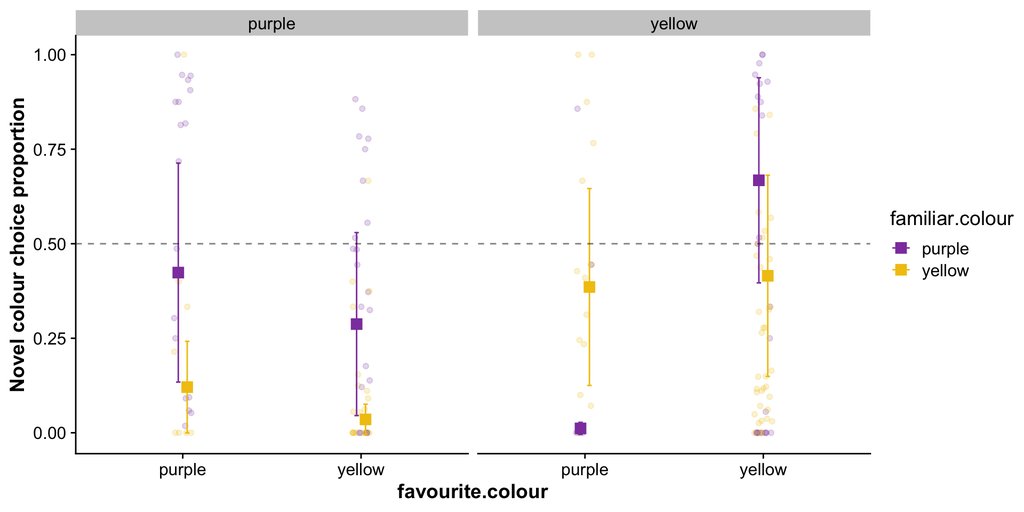

Figure 2: This plot separates the data into 2 panels by session rewarding colour. Data are means ± SE

## Plot Graveyard

Here I have plots of things I want to visualize, nothing final present here.

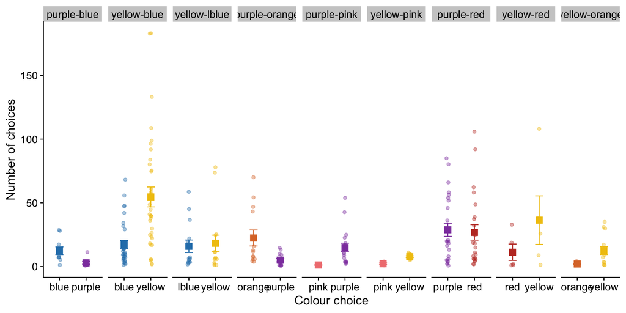

Figure 3: Data are means ± SE.

#### Corrections

If you see mistakes or want to suggest changes, please [create an issue](https://github.com/wyatt-toure/heliconius-exploration/issues/new) on the source repository.

#### Reuse

Source code is available at https://github.com/wyatt-toure/heliconius-exploration